# Stochastic SIR model using odin

Thibaut Jombart, Rich FitzJohn

2018-10-02

# Basic model

The stochastic equivalent of the previous model can be formulated in `odin` as follows:

```r
model_file <- "odin_model.R"
```

```r
## Core equations for transitions between compartments:
update(S) <- S - n_SI
update(I) <- I + n_SI - n_IR
update(R) <- R + n_IR

## Individual probabilities of transition:
p_SI <- 1 - exp(-beta * I / N) # S to I
p_IR <- 1 - exp(-gamma) # I to R

## Draws from binomial distributions for numbers changing between
## compartments:
n_SI <- rbinom(S, p_SI)
n_IR <- rbinom(I, p_IR)

## Total population size
N <- S + I + R

## Initial states:
initial(S) <- S_ini
initial(I) <- I_ini
initial(R) <- 0

## User defined parameters - default in parentheses:
S_ini <- user(1000)
I_ini <- user(1)
beta <- user(0.2)
gamma <- user(0.1)
```

We can use the same workflow as before to run the model, using 10 initial infected individuals (`I_ini = 10`):

```r
sir_generator <- odin::odin(model_file, verbose = FALSE)
sir_generator
## function (S_ini = NULL, I_ini = NULL, beta = NULL, gamma = NULL,
##     user = list(S_ini = S_ini, I_ini = I_ini, beta = beta, gamma = gamma))
## <an 'odin_generator' function>
##   use coef() to get information on user parameters
x <- sir_generator(I_ini = 10)
```

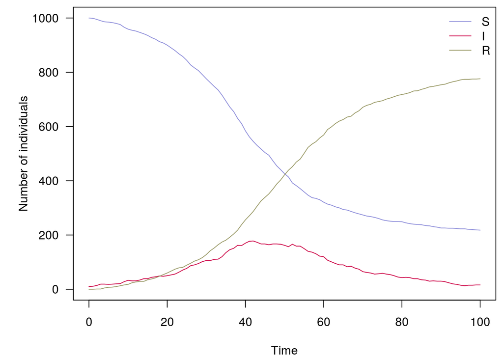

*An example of stochastic, discrete-time SIR model*

```r
set.seed(1)
sir_col <- c("#8c8cd9", "#cc0044", "#999966")

res <- x$run(0:100)
par(mar = c(4.1, 5.1, 0.5, 0.5), las = 1)
matplot(res[, 1], res[, -1], xlab = "Time", ylab = "Number of individuals",
        type = "l", col = sir_col, lty = 1)
legend("topright", lwd = 1, col = sir_col, legend = c("S", "I", "R"), bty = "n")
```

This gives us a single stochastic realisation of the model, which is of limited interest.

# Generating replicates

Stochastic models become interesting when multiple *replicates* (i.e. independent stochastic realisations of the model) can be generated. *odin* implements a straightforward interface for this, which we illustrate below.

First, let’s have a look at the arguments of the `run` function of our new object:

```r
args(x$run)
## function (step, y = NULL, ..., use_names = TRUE, replicate = NULL)
## NULL
```

`replicate` can take an `integer` indicating the number of independent realisations of the model we are after. Let’s start with 200:

```r
res_200 <- x$run(0:100, replicate = 200)
dim(res_200)
```

```
## [1] 101   4 200
```

`res_200` is now a 3-dimensional array storing results for all time steps, compartments and replicates. The function `x$transform_variables` will be very handy to reformat these results into something we can plot and analyse:

```r
res_200 <- x$transform_variables(res_200)
class(res_200)
```

```
## [1] "list"
```

```r
length(res_200)
```

```
## [1] 4
```

```r
names(res_200)
```

```
## [1] "t" "S" "I" "R"
```

```r
dim(res_200[[1]])
## NULL
```

`res_200` is now a list where every compartment is stored separately; this can be easily coerced into a `data.frame` for further plotting:

```r
res_200 <- cbind.data.frame(t = res_200[[1]], res_200[-1])
dim(res_200)
```

```
## [1] 101 601
```

```r
res_200[1:10, 1:4]
```

```
##    t  S.1  S.2  S.3
## 1  0 1000 1000 1000
## 2  1  999  999  996
## 3  2  998  995  993
## 4  3  996  992  986
## 5  4  995  989  983
## 6  5  992  984  981
## 7  6  991  981  978
## 8  7  986  977  975
## 9  8  984  974  972
## 10 9  978  971  969
```

Let us define colors for our plot:

```r
## function to make colors transparent, stolen from adegenet::transp
transp <- function (col, alpha = 0.5) {
    res <- apply(col2rgb(col), 2,
                 function(c) rgb(c[1]/255, c[2]/255,
                                 c[3]/255, alpha))
    return(res)
}

col <- rep(transp(sir_col, .1), each = 200)
```

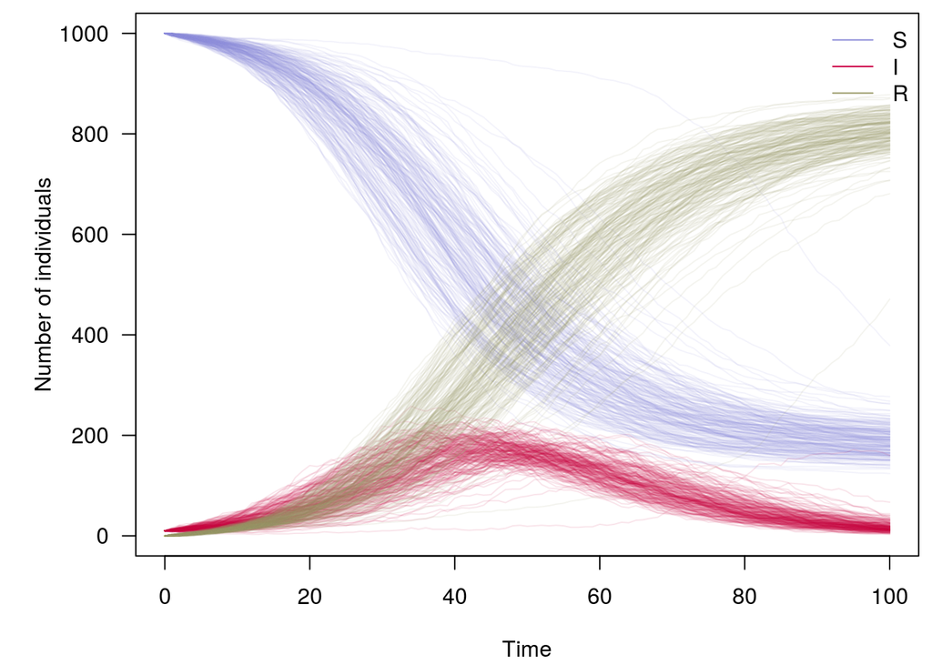

```r
par(mar = c(4.1, 5.1, 0.5, 0.5), las = 1)
matplot(res_200[, 1], res_200[, -1], xlab = "Time", ylab = "Number of individuals",
        type = "l", col = col, lty = 1)
legend("topright", lwd = 1, col = sir_col, legend = c("S", "I", "R"), bty = "n")
```

## A handy wrapper for replicates

The steps illustrated in the previous section can be wrapped into a simple function:

```r
## x: instance of odin model
## t: time steps
## n: number of replicates
run_model <- function(x, t = 0:100, n = 1, ...) {
    res <- x$run(t, replicate = n, ...)
    res <- x$transform_variables(res)
    res <- cbind.data.frame(t = res[[1]], res[-1])
    attr(res, "n_compartments") <- length(x$names) - 1
    attr(res, "n_replicates") <- n
    attr(res, "compartments") <- x$names[-1]
    class(res) <- c("pretty_odin", class(res))
    res
}

sir_pal <- colorRampPalette(sir_col)

plot.pretty_odin <- function(x, pal = sir_pal, ...) {
    ## handle colors
    n_compartments <- attr(x, "n_compartments")
    n_replicates <- attr(x, "n_replicates")
    col_leg <- pal(n_compartments)
    alpha <- max(10 / n_replicates, 0.01)
    col <- rep(transp(col_leg, alpha), each = n_replicates)

    ## make plot
    par(mar = c(4.1, 5.1, 0.5, 0.5), las = 1)
    matplot(x[, 1], x[, -1], xlab = "Time", ylab = "Number of individuals",
            type = "l", col = col, lty = 1, ...)
    legend("topright", lwd = 1, col = col_leg, bty = "n",
           legend = attr(x, "compartments"))
}
```

Here are two examples with 20 time steps, 50 simulations:

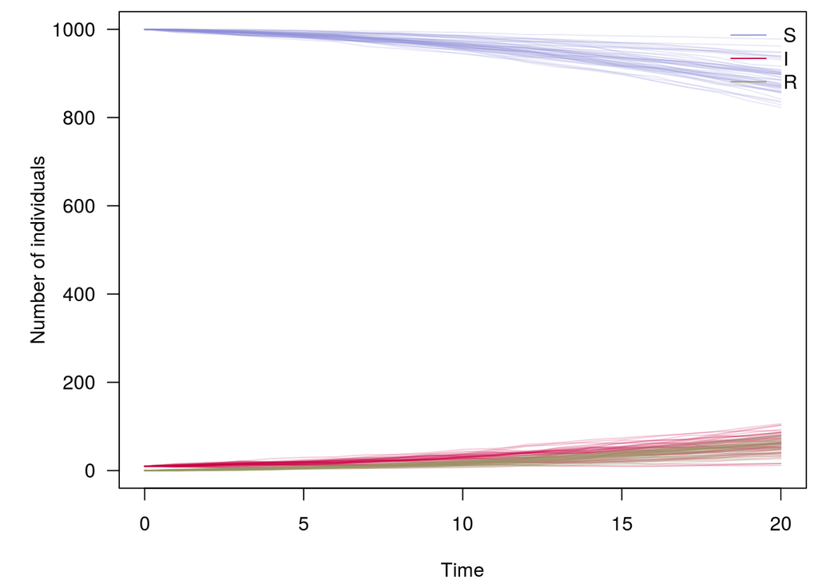

```r
plot(run_model(x, t = 0:20, n = 50))
```

and another one using 100 timesteps and 500 replicates:

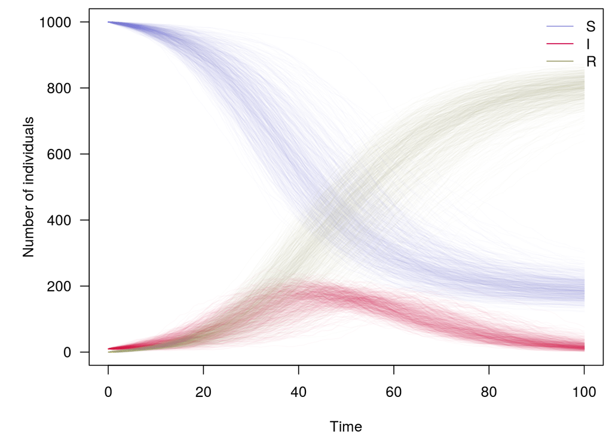

```r
plot(run_model(x, t = 0:100, n = 500))
```